# Vivo_Analysis

> Analysis of 3'UTR usage in neural stem cells of the subventricular zone (from Kalamakis et al. 2019)

Final plots in the paper may differ slightly due to:

- figures are not in order as in the paper (due to the intrinsic logic of this script and the input data)
- changes pending on the peer-review process
- collecting and final editing of sub-plots in Adobe Illustrator
- differences R package versions or other parameters

> Note: This is a reporting file providing all the necessary programming code to comprehend the main results of the paper.

> Note: Precompield files are provided in this directory.

> Note: Computed as HTML-File

## Downstream Analysis of in-vivo 3'UTRs (young + old NSCs)

## ... load the previously created 3'mapping file

```r
# load the stored 3'UTR object
load(file = '/Volumes/g381-daten2/goepferich/3UTR_REANALYSIS_2019/vivo_downstream/vivoFiltered.rda')
```

## ... some basic metrices & 3'tail-peak analysis

```r
length( vivoFiltered@NAMES ) # number of exons
```

```
## [1] 14305
```

```r
length( unique( names(vivoFiltered@NAMES ) ) ) # number of genes
```

```
## [1] 12107
```

```r
sum( tapply(vivoFiltered@NAMES, names(vivoFiltered@NAMES), length ) > 1 ) # number of genes with multiple exons (used)
```

```
## [1] 1479
```

```r
apa <- get_mfsc(vivoFiltered, 'features' ) %>% unlist()
apa <- apa > 1
table(apa) # TRUE, exons with APA events
```

```
## apa
## FALSE  TRUE
##  5400  8905
```

```r
# subset to genes with only (potentially) APA events
apaFiltered <- vivoFiltered[apa]
```

## ... create some nice lists with the S4 approach

> These lists are required for the transcript-by-transcript approach

```r
# create lists of the required input-values
ctab_list <- get_mfsc(apaFiltered, 'counts')
clen_list <- get_mfsc(apaFiltered, 'cellMean')
peak_list <- get_mfsc(apaFiltered, 'peaks')
supp_list <- get_mfsc(apaFiltered, 'support')
anno_list <- get_annotation(apaFiltered)

# The list of isoform count tables!
str( head(ctab_list, n = 2) )
```

```
## List of 2
##  $ ENSMUSG00000025903_5: int [1:453, 1:3] 0 0 0 0 0 0 0 0 0 0 ...
##   ..- attr(*, "dimnames")=List of 2
##   .. ..$ : chr [1:453] "AAACCTGAGGAATCGC-2" "AAACGGGCAGCAGTTT-1" "AAAGATGTCTGGCGAC-2" "AAAGCAACAGTTAACC-2" ...
##   .. ..$ : NULL
##  $ ENSMUSG00000033813_2: int [1:466, 1:2] 0 0 0 1 0 1 0 2 0 0 ...
##   ..- attr(*, "dimnames")=List of 2
##   .. ..$ : chr [1:466] "AAACCTGTCCAGAGGA-2" "AAAGATGGTGCAGACA-2" "AACACGTCAAATCCGT-2" "AACCATGAGGCTCAGA-1" ...
##   .. ..$ : NULL
```

```r
# The list of 3'UTR lengths!
str( head(clen_list, n = 2) )
```

```
## List of 2
##  $ ENSMUSG00000025903_5: num [1:453] 1773 1772 1772 1772 1767 ...
##  $ ENSMUSG00000033813_2: num [1:466] 320 280 334 40 320 40 332 40 320 320 ...
```

```r
# The list of matched cell annotations
str( head(anno_list, n = 2) )
```

```
## List of 2
##  $ ENSMUSG00000025903_5: tibble [453 × 4] (S3: tbl_df/tbl/data.frame)
##   ..$ CellBarcode: chr [1:453] "AAACCTGAGGAATCGC-2" "AAACGGGCAGCAGTTT-1" "AAAGATGTCTGGCGAC-2" "AAAGCAACAGTTAACC-2" ...
##   ..$ CellType   : chr [1:453] "TAP" "qNSC2" "aNSC2" "aNSC2" ...
##   ..$ CellAge    : chr [1:453] "young" "old" "young" "young" ...
##   ..$ pTime      : num [1:453] 29.5 10.7 24.2 24.1 20.8 ...
##  $ ENSMUSG00000033813_2: tibble [466 × 4] (S3: tbl_df/tbl/data.frame)
##   ..$ CellBarcode: chr [1:466] "AAACCTGTCCAGAGGA-2" "AAAGATGGTGCAGACA-2" "AACACGTCAAATCCGT-2" "AACCATGAGGCTCAGA-1" ...
##   ..$ CellType   : chr [1:466] "aNSC1" "TAP" "TAP" "aNSC2" ...
##   ..$ CellAge    : chr [1:466] "young" "young" "young" "old" ...
##   ..$ pTime      : num [1:466] 8.5 26.3 28.4 22.1 20 ...
```

## ... multinomial regreossion analysis with the 'nnet' package

> First separately for both samples (young + old) using LRT-statistic

> The hypothesis is that 3'UTR isoform choice changes with pseudotime (NSC lineage progression)

```r
# apply multinomial regression
young_stat <- mapply(function(x, y, dof){
            if(sum(y$CellAge == 'young') > 9 & sum(colSums(x[y$CellAge == 'young', ,drop= F]) > 1) > 1 ){
            x <- x[y$CellAge == 'young', ,drop= F]
            y <- y[y$CellAge == 'young', ,drop = F]
            # compute the multinomial regression
                    fit1 <- nnet::multinom(x ~  bs(y$pTime, df = 5), trace = FALSE )
                    fit0 <- nnet::multinom(x ~ 1, trace = FALSE )
            pval <- anova(fit1, fit0)$'LR stat.'[2]
            } else {
              pval <- NA
            }
              return(pval)
}, x = ctab_list, y = anno_list, SIMPLIFY = FALSE )
young_stat <- unlist2(young_stat)

old_stat <- mapply(function(x, y, dof){
            if(sum(y$CellAge == 'old') > 9 & sum(colSums(x[y$CellAge == 'old', ,drop= F]) > 1) > 1 ){
            x <- x[y$CellAge == 'old', ,drop= F]
            y <- y[y$CellAge == 'old', ,drop = F]
            # compute the multinomial regression
                    fit1 <- nnet::multinom(x ~  bs(y$pTime, df = 5), trace = FALSE )
                    fit0 <- nnet::multinom(x ~ 1, trace = FALSE )
            pval <- anova(fit1, fit0)$'LR stat.'[2]
            } else {
              pval <- NA
            }
              return(pval)
}, x = ctab_list, y = anno_list, SIMPLIFY = FALSE )
old_stat <- unlist2(old_stat)

cor(old_stat, young_stat, use = "pairwise.complete.obs")
```

```
## [1] 0.8551773
```

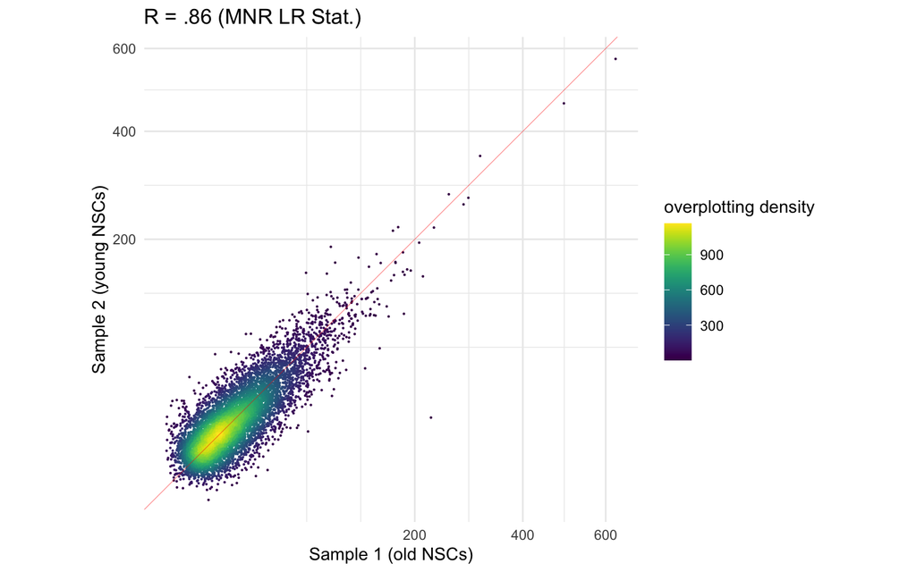

```r
lrt_sample_tbl <- tibble(Gene = names(old_stat), Sample_1 = old_stat, Sample_2 = young_stat)

gg_lrt <- ggplot(lrt_sample_tbl, aes(x = Sample_1, y = Sample_2)) +
  geom_pointdensity(size = .1) +
  xlim(c(-10, 625)) + ylim(c(-10, 625)) + # exclude some outliers from the plotting
  ggtitle('R = .86 (MNR LR Stat.)') +
  scale_color_viridis() +
  theme_minimal() +
  coord_equal() +
  scale_y_sqrt() + scale_x_sqrt() +
  labs(colour = 'overplotting density') +
  labs(x = 'Sample 1 (old NSCs)', y = 'Sample 2 (young NSCs)') + coord_equal() +
  geom_abline(slope =1, colour = 'red', size = .1, intercept = 0)

gg_lrt
```

## ... compute the correlations of 3'UTR length vs. pseudotime

> This represents a metric for lengthening/shortening of the 3'UTR with NSC lineage progression

```r
# Run the correlation test for both samples

yng_cor <- mapply(function(x, y){
              isyoung   <- y$CellAge == 'young'
              if( sum(isyoung) > 9 & sum(!isyoung) > 9 ){
              z1 <- cor(x[isyoung], y$pTime[isyoung])
              z2 <- cor.test(x[isyoung], y$pTime[isyoung], 'greater')$p.value
              z3 <- cor.test(x[isyoung], y$pTime[isyoung], 'less')$p.value
              } else {
                z1 <-  NA; z2 <- NA; z3 <- NA
              }
              return(c(z1, z2, z3))
}, x = clen_list, y = anno_list,  SIMPLIFY = FALSE)

yng_corr  <- sapply( yng_cor, function(x){ x[1] } )
yng_test1 <- sapply( yng_cor, function(x){ x[2] } )
yng_test2 <- sapply( yng_cor, function(x){ x[3] } )

old_cor <- mapply(function(x, y){
              isyoung   <- y$CellAge == 'old'
              if( sum(isyoung) > 9 & sum(!isyoung) > 9 ){
              z1 <- cor(x[isyoung], y$pTime[isyoung])
              z2 <- cor.test(x[isyoung], y$pTime[isyoung], 'greater')$p.value
              z3 <- cor.test(x[isyoung], y$pTime[isyoung], 'less')$p.value
              } else {
                z1 <-  NA; z2 <- NA; z3 <- NA
              }
              return(c(z1, z2, z3))
}, x = clen_list, y = anno_list,  SIMPLIFY = FALSE)

old_corr  <- sapply( old_cor, function(x){ x[1] } )
old_test1 <- sapply( old_cor, function(x){ x[2] } )
old_test2 <- sapply( old_cor, function(x){ x[3] } )

# Now, one can subset to the genes with significant (i.e. reproducible) genes

sig_lng <- which(old_test1 < .1 & yng_test1 < .1)
length(sig_lng)
```

```
## [1] 496
```

```r
sig_sht <- which(old_test2 < .1 & yng_test2 < .1)
length(sig_sht)
```

```
## [1] 320
```

> These numbers do not perfectly align with those in the figure (in the paper) since these are still transcript counts (a gene can have multiple terminal exons with APA).

## ... plot these correlations!

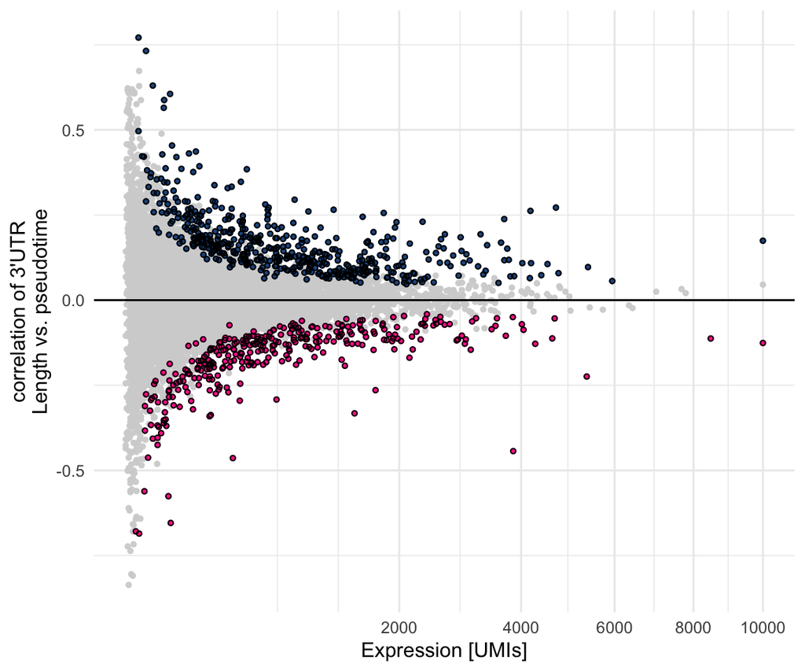

```r
# dummy vector for the 3'UTR trends
trend <- rep(NA, times = length(apaFiltered@NAMES))
trend[sig_sht] <- 'shorter'
trend[sig_lng] <- 'longer'

# average correlations
corr <- mapply(function(x, y){cor(x, y$pTime) }, x = clen_list, y = anno_list,  SIMPLIFY = TRUE)

# a table for plotting
vivo_cor_tbl <- tibble(Gene = apaFiltered@NAMES,      # Gene Names
                       UMIs = sapply(supp_list, sum),  # total UMIs
                       Corr_Yng = yng_corr,
                       Corr_Old = old_corr,
                       Corr_Both = corr,
                       Trend = trend
                       )

# restrict genes with extremly high expression (ouliers for plotting)
vivo_cor_tbl$UMIs[vivo_cor_tbl$UMIs > 10000] <- 10000

gg_corr_ma <- ggplot(vivo_cor_tbl, aes(y = Corr_Both, x =  UMIs, colour = Trend )) +
  geom_point( data = filter(vivo_cor_tbl, is.na(trend)), size = .95, alpha = .95) +
  geom_point(data = filter(vivo_cor_tbl, !is.na(trend)), size = .95, alpha = .95) +
  geom_point( data = filter(vivo_cor_tbl, !is.na(trend)), size = .95, shape = 1, color = 'black') +
  geom_hline(yintercept = 0, col = 'black') +
  theme_minimal() +
  #theme(legend.position = 'top') +
  scale_x_sqrt( breaks = scales::pretty_breaks(n = 4) ) +
  scale_colour_manual(values = c('dodgerblue4', 'deeppink'), na.value = 'lightgrey') +
  labs(x = 'Expression [UMIs]', y = "correlation of 3'UTR\nLength vs. pseudotime") +
  guides(colour = FALSE)

gg_corr_ma
```

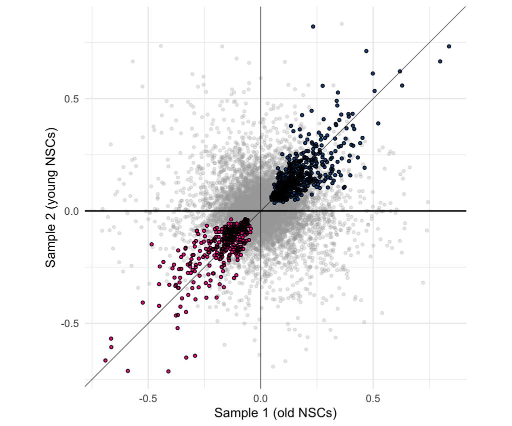

```r
# now, a nomial correlation test
corr_test <- mapply(function(x, y){ cor.test(x, y$pTime)$p.value }, x = clen_list, y = anno_list,  SIMPLIFY = TRUE)
vivo_cor_tbl$Nominal <- p.adjust( corr_test, method = 'fdr') < .1

# show the agreement of both samples (whenever the correlation is nomianlly significant)
gg_corr_rp <- ggplot(vivo_cor_tbl, aes(y = Corr_Yng, x =  Corr_Old, colour = Trend )) +
  geom_point( data = filter(vivo_cor_tbl, is.na(trend)), size = .95, alpha = .25, color = 'darkgrey') +
  geom_point(data = filter(vivo_cor_tbl, !is.na(trend)), size = .95, alpha = .95) +
  geom_point( data = filter(vivo_cor_tbl, !is.na(trend)), size = .95, shape = 1, color = 'black') +
  geom_hline(yintercept = 0, col = 'black') +
  theme_minimal() +
  scale_colour_manual(values = c('dodgerblue4', 'deeppink'), na.value = 'lightgrey') +
  geom_abline(slope = 1, intercept = 0, color = 'black', size = .2) +
  geom_hline(yintercept = 0, size = .2, alpha = .95, color = 'black') +
  geom_vline(xintercept = 0, size = .2, alpha = .95, color = 'black') +
  coord_equal() +
  guides(color = FALSE) +
  labs(x = 'Sample 1 (old NSCs)', y = 'Sample 2 (young NSCs)')

gg_corr_rp
```

## ... plot 3'UTR usage for a single gene, here Pea15a!

> This is an example, plotting parameters need to be adjusted for other genes

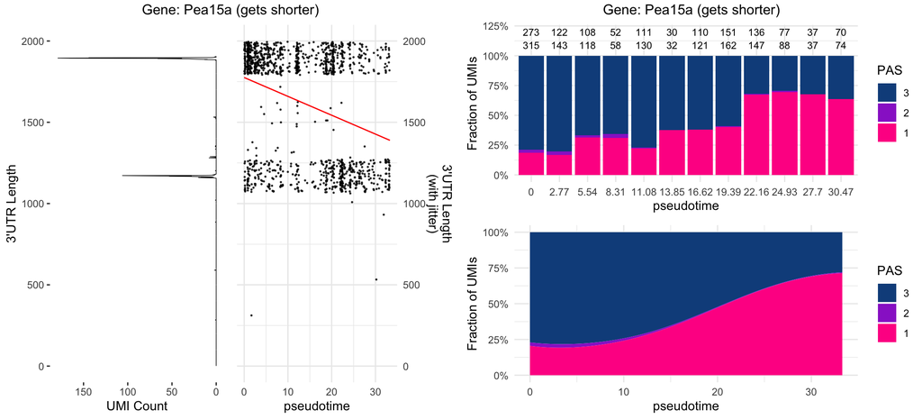

```r
# step 1: subset to the gene of interest
y   <- anno_list$ENSMUSG0000001369
x   <- ctab_list$ENSMUSG0000001369
val <- colSums(x) > 9 # exclude isoforms with less than 10 UMIs
x   <- x[ ,val ]
ix  <- rowSums(x) > 0 # exclude cells with no counts (after rare isoform exclusion)
y   <- y[ix, ]
x   <- x[ix, ]
dof <- 3 # use 3 degrees of freedom for the spline regression

# step 2: compute discrete windows of pseudotime (lineage prgression)
bins <- seq(0, max(y$pTime), by = 2.77)
wind <- lapply( bins, function(x){ which(y$pTime > x & y$pTime < x + 2.77) } )
wind <- wind[1:12]
per_wind <- lapply(wind, function(x, mat){ out <- colSums( mat[x, ] ); (out/sum(out))  }, mat = x)
tbl <- tibble( Ratio = unlist(per_wind),
               Peaks = factor(rep(1:3, 12), levels = c('3', '2', '1')),
               Bins = as.factor( rep(bins[1:12], each = 3)) )

umi_wind <- sapply(wind, function(x, mat){ sum( mat[x, ] )  }, mat = x)
cell_wind <- sapply(wind, function(x, mat){ sum( mat[x, ] > 0 )  }, mat = x)
quant1 <- tibble(x = 1:12, y = 1.09, value = umi_wind)
quant2 <- tibble(x = 1:12, y = 1.2, value = cell_wind)

f1f1 <- ggplot(tbl, aes(x = Bins, y = Ratio)) +
  geom_col(mapping = aes(fill = Peaks)) +
  theme_minimal() +
  scale_fill_manual(values = rev(c("deeppink", 'darkorchid3', 'dodgerblue4')) ) +
  geom_text( data = quant1, mapping = aes(label = value, x= x, y = y), size = 3) +
  geom_text( data = quant2, mapping = aes(label = value, x= x, y = y), size = 3) +
  scale_y_continuous(labels = scales::percent) +
  labs(y = 'Fraction of UMIs', x = 'pseudotime', fill = 'PAS')


# step 3: now with the spline regression

                    fit1 <- nnet::multinom(x ~  bs(y$pTime, df = dof), trace = FALSE )
                    fit0 <- nnet::multinom(x ~ 1, trace = FALSE )
                    m <- cbind( 1, bs( y$pTime, df = dof ) ) %*% t(coef(fit1))
                    m <- exp( cbind( iso1 = 0, m ) )
                    m <- m / rowSums(m)
                    colnames(m) <- seq_len(ncol(m))
                    m  <- m[order(y$pTime), ]

peak_tbl <- tibble(Peaks      =  factor(rep(1:3, length(y$pTime)),
                                          levels = c('3', '2', '1')),
                   PseudoTime = rep(sort(y$pTime), each = 3),
                   Sample     = rep(y$CellAge[order(y$pTime)], each = 3),
                   Ratio      = unlist(apply(m, 1, list)) )

f1f2 <- ggplot(peak_tbl, aes(x = PseudoTime,
                     y = Ratio,
                     fill = Peaks)) +
                     geom_area() +
  scale_fill_manual(values = rev(c("deeppink", 'darkorchid3', 'dodgerblue4')) ) +
  theme_minimal() +
  scale_y_continuous(labels = scales::percent) +
  labs(y = 'Fraction of UMIs', x = 'pseudotime', fill = 'PAS')

# step 4: combine both plots
f1f <- arrangeGrob(f1f1, f1f2, ncol = 1, top = 'Gene: Pea15a (gets shorter)')
#f1f

# step 5: ... plot 3'UTR length vs. pseudotime
pa_pt_tbl <- tibble( len = clen_list$ENSMUSG0000001369, pt = anno_list$ENSMUSG0000001369$pTime )

set.seed(1001) # random seed for the jitter function
f1b1 <- ggplot(pa_pt_tbl, aes(x = pt, y = len)) + geom_jitter(size = .25, height = 100, alpha = .75) +
  geom_smooth(method = 'lm', fill = NA, colour = 'red', size = .5) +
  theme_minimal() + scale_y_continuous(position = "right",
                                       limits = c(0, 2000 )) +
  labs(y = "3'UTR Length\n(with jitter)", x = 'pseudotime')

# step 6: ... for plotting, write the read coverage (3'peaks) into a table
cv         <- apaFiltered@listData$ENSMUSG0000001369@coverage
pa_reg_tbl <- tibble(UMI_Count = cv, Position = seq_along(cv) )

f1b2 <- ggplot(pa_reg_tbl) + geom_path(aes(x = Position, y = UMI_Count ), size = .25) +
  scale_colour_manual( values = c('firebrick4', 'dodgerblue4') , na.value = 'white') +
  theme(legend.position = 'bottom', panel.background = element_rect(fill = "white", colour ="white")) +
  coord_flip() + scale_y_reverse( ) + xlim(c(0, 2000)) + labs(x = "3'UTR Length", y = 'UMI Count')

# ... combine both plots
f1b <- arrangeGrob(f1b2, f1b1, ncol = 2, top = 'Gene: Pea15a (gets shorter)')
#f1b

# ... eventually, combine all four plots!
grid.arrange(f1b, f1f, ncol = 2)
```

## Compute a quality control as position of annotated 3'UTR ends and the polyadenylation signal (PAS)

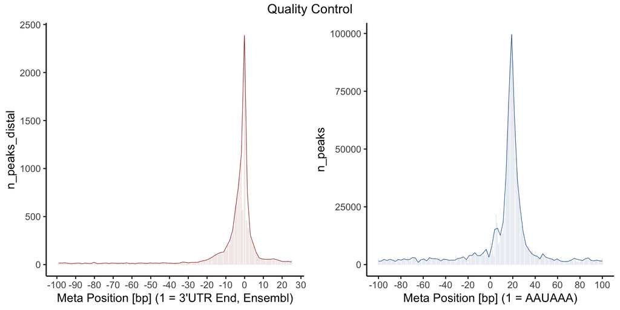

```r
## meta-peak from Ensembl
ldx           <- vivoFiltered@Sequence$Length > 99  # exclude very short UTRs
metaend      <- mapply(function(x, y){
   distal    <- x[ (y - 100):(y + 24)  ]
   ifelse(any(distal > 0), which.max(distal), NA)
   }, x = get_mfsc(vivoFiltered, 'coverage')[ldx],
  y = vivoFiltered@Sequence$Length[ldx])

metapeak <- tabulate(metaend, nbins = 125) # tabulate

shift_tbl <- tibble(n_peaks_distal = metapeak,
                    MetaPosition = (-99):(25))
# plot it
gg_dist_ensembl <- ggplot(shift_tbl, aes(y = n_peaks_distal, x = MetaPosition) ) +
   theme_classic() + geom_col(fill = 'firebrick4', alpha = .1 ) +
   geom_smooth(method = 'loess', span = .02, se = FALSE, size = .2, colour = 'firebrick4') +
   labs(x = "Meta Position [bp] (1 = 3'UTR End, Ensembl)" ) +
   scale_x_continuous(breaks = scales::pretty_breaks(n = 10)) +
   theme(legend.position = 'bottom')

# meta-peak from the Hexamer
distHex      <- mapply(function(x, y){
      hexPos <- gregexpr('AATAAA', y)[[1]] %>% as.vector()
      hexPos <- hexPos[hexPos > 100]
      cov    <- tabulate(x@peaks[x@support > 1])
      if(length(hexPos) > 0){
      out    <- lapply( hexPos, function(x, y){ y[ (x - 100):(x + 100) ] }, y = cov)
      } else {
        out <- NULL
      }
      return(out)
   }, y = vivoFiltered@Sequence$Seqeuence, x = vivoFiltered@listData) %>% unname()

distHex <- distHex[!sapply(distHex, is.null)  ] #%>% unlist2( ,de)
distHex <- unlist(distHex, recursive = F)
distHex <- do.call('rbind', distHex)
distHex <- apply(distHex, 1, function(x){ ( x/sum(x)*201 ) })
distHex  <- rowSums(distHex, na.rm = T)

shift_tbl <- tibble(n_peaks = distHex,
                    MetaPosition = (-100):(100))

gg_hex_pos <- ggplot(shift_tbl, aes(y = n_peaks, x = MetaPosition) ) +
   theme_classic() + geom_col(fill = 'dodgerblue4', alpha = .1 ) +
   geom_smooth(method = 'loess', span = .01, se = FALSE, size = .2, colour = 'dodgerblue4') +
   labs(x = "Meta Position [bp] (1 = AAUAAA)" ) +
   scale_x_continuous(breaks = scales::pretty_breaks(n = 10)) +
   theme(legend.position = 'bottom')

grid.arrange(gg_dist_ensembl, gg_hex_pos, ncol = 2, top = 'Quality Control')
```

## Perform gene set enrichment analysis using the multinomial regression score (Gene Ontology - GO and disease ontology - DO)

> This chunk shows the example code; results will vary with the random seed and the version of the annotation packages

```r
score <- (old_stat + young_stat)/2
names(score) <- eff_tbl$Genes
score <- sort(score, decreasing = TRUE)
str(score)

set.seed(101)
require(clusterProfiler)
require(org.Mm.eg.db)
gsl <- gseGO(geneList = score, ont = 'BP', OrgDb = 'org.Mm.eg.db', keyType = "ENSEMBL", pvalueCutoff = 0.1, nPerm = 25000, minGSSize = 20)
gsl@result


require("biomaRt")
human = useMart("ensembl", dataset = "hsapiens_gene_ensembl")
mouse = useMart("ensembl", dataset = "mmusculus_gene_ensembl")
score_h <- getLDS(attributes = c("ensembl_gene_id"),
                  filters = "ensembl_gene_id", values = names(score),
                  mart = mouse, attributesL = c("entrezgene_id"),
                  martL = human, uniqueRows=T)#[ ,2]
str(score_h)


anyDuplicated(score_h$Gene.stable.ID)
score_ <- score[score_h$Gene.stable.ID]
names(score_) <- as.character(score_h$NCBI.gene.ID)
score_ <- sort(score_, decreasing = TRUE)

set.seed(101)
do <- gseDO(score_, minGSSize = 20, pvalueCutoff = .05,  nPerm = 10000)
do@result$Description
do_ <- do@result[c(1,2,6, 16, 46), ]

set.seed(101)
dgn <- gseDGN(score_, minGSSize = 20, pvalueCutoff = .05, nPerm = 10000 )
dgn@result
```

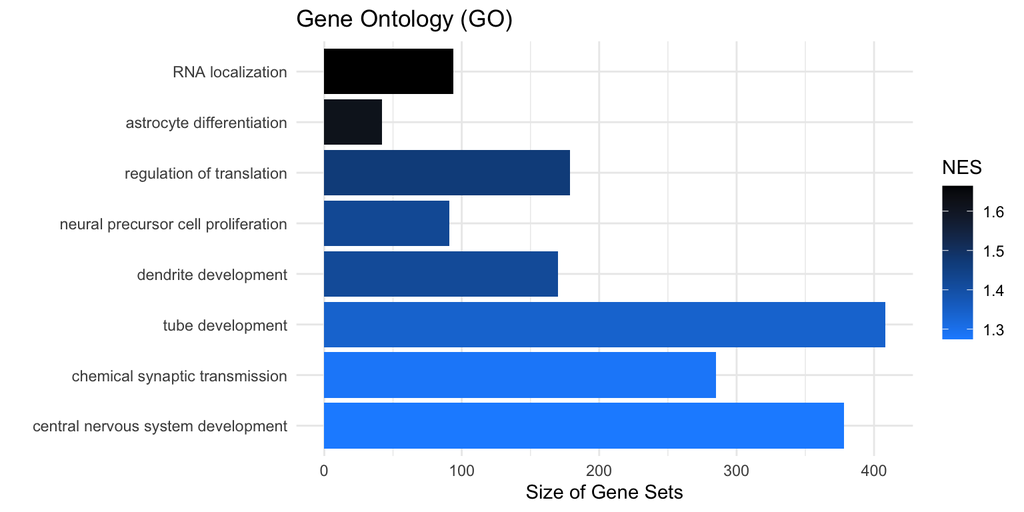

```r
# Load the precompiled result
load(file = 'gsea_vivo.rda')

f1g <- ggplot( gsl_sub, aes(y = setSize, x = Description, fill = NES ) ) +
           geom_col() + coord_flip() + ggtitle('Gene Ontology (GO)') +
           theme_minimal() +
           labs(x = '', y = 'Size of Gene Sets') +
           scale_fill_gradientn( colors = c('dodgerblue1', 'dodgerblue4', 'black') )
# GSEA (Rank by Lengthening), FDR < 10%
f1g
```

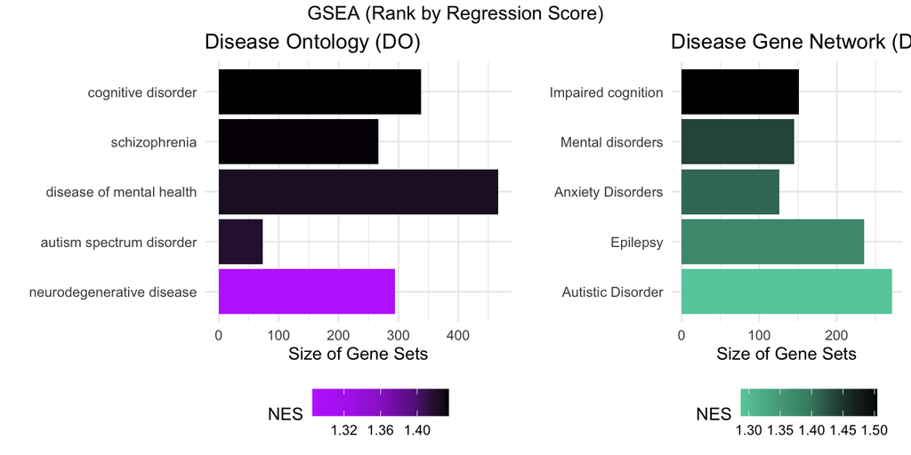

```r
do_ <- mutate(do_, Description = factor(Description, levels = (Description)[order(NES)]  ) )
f1h1 <- ggplot( do_, aes(y = setSize, x = Description, fill = NES ) ) +
        geom_col() + coord_flip() +
        ggtitle("Disease Ontology (DO)") + theme_minimal() +
        labs(x = '', y = 'Size of Gene Sets') +
        scale_fill_gradientn( colors = c('darkorchid1', 'darkorchid2', 'darkorchid3', 'darkorchid4', 'black') ) +
        theme(legend.position = 'bottom')
#f1h1

dgn_ <- mutate(dgn_, Description = factor(Description, levels = (Description)[order(NES)]  ) )
f1h2 <- ggplot( dgn_, aes(y = setSize, x = Description, fill = NES ) ) +
        geom_col() + coord_flip() +
        ggtitle("Disease Gene Network (DGN)") + theme_minimal() +
        labs(x = '', y = 'Size of Gene Sets') +
        scale_fill_gradientn( colors = c('aquamarine3', 'aquamarine4', 'black') ) +
        theme(legend.position = 'bottom')
#f1h2
grid.arrange(f1h1, f1h2, ncol = 2, top = 'GSEA (Rank by Regression Score)', widths = c(4, 3))
```

## Identification of CPE-flanked isoforms and their usage along the neural stem cell lineage

> This chunk shows the example code

```r
nom_th <- p.adjust( sapply(mnrg_list, function(x){ x$p.value }), method = 'fdr') < .01

cpe_cnt <- mapply(function(x, y, z, s){
  m <- 'TTTTGT|TTTTGAT|TTTTAGT'
  loc <- (str_locate_all(y, m)[[1]][ ,1])
  pos <- sapply(z, function(x, loc){ any(x - loc > 5 & x - loc < 55) }, loc)
  th <- s > 149
  pt   <- sort(x$pTime)
  corr <- apply(x$spline_matrix, 2, function(x){
             cor(x[pt < 21], pt[pt < 21] ) } )

  pce <- corr[which(pos & th)]
  ncpe <- corr[which(!pos & th)]
  if( any(th) ){
    return(list( Positive = pce[1], Negative = ncpe[1] ))
  } else {
    return(NULL)
  }
  },
  y = apaFiltered@Sequence$Seqeuence, s = supp_list,
  x = mnrg_list, z = peak_list, SIMPLIFY = FALSE
  ) %>% unname()

anyPos <- lapply( cpe_cnt, function(x){ is.numeric(x$Positive) &
                                        length(x$Positive) > 0 } ) %>% unlist2()

pos <- lapply( cpe_cnt, function(x){ x$Positive } )[nom_th & anyPos] %>% unlist2()
neg <- lapply( cpe_cnt, function(x){ x$Negative } )[nom_th & anyPos] %>% unlist2()
pos <- pos[!is.na(pos)]
neg <- neg[!is.na(neg)]
str(pos)
str(neg)
boxplot(pos, neg)
wilcox.test(pos, neg)
cpe_cor_tbl1 <- tibble( Cor = c(pos, neg),
               Peak = c( rep('CPE', length(pos)), rep('No CPE', length(neg)) ),
               Transition = 'qNSCs to aNSCs')

cpe_cnt <- mapply(function(x, y, z, s){
  m <- 'TTTTGT|TTTTGAT|TTTTAGT'
  loc <- (str_locate_all(y, m)[[1]][ ,1])
  pos <- sapply(z, function(x, loc){ any(x - loc > 5 & x - loc < 55) }, loc)
  th <- s > 149
  pt   <- sort(x$pTime)
  corr <- apply(x$spline_matrix, 2, function(x){
             cor(x[pt > 22], pt[pt > 22] ) } )

  pce <- corr[which(pos & th)]
  ncpe <- corr[which(!pos & th)]
  if( any(th) ){
    return(list( Positive = pce[1], Negative = ncpe[1] ))
  } else {
    return(NULL)
  }
  },
  y = apaFiltered@Sequence$Seqeuence, s = supp_list,
  x = mnrg_list, z = peak_list, SIMPLIFY = FALSE
  ) %>% unname()

pos <- lapply( cpe_cnt, function(x){ x$Positive } )[nom_th & anyPos] %>% unlist2()
neg <- lapply( cpe_cnt, function(x){ x$Negative } )[nom_th & anyPos] %>% unlist2()
boxplot(pos, neg)
wilcox.test(pos, neg)
pos <- pos[!is.na(pos)]
neg <- neg[!is.na(neg)]
str(pos)
str(neg)

cpe_cor_tbl2 <- tibble( Cor = c(pos, neg),
               Peak = c( rep('CPE', length(pos)), rep('No CPE', length(neg)) ),
               Transition = 'aNSCs to NBs')

cpe_cor_tbl <- rbind(cpe_cor_tbl1, cpe_cor_tbl2) %>% as_tibble()
```

```r
# Load the precompiled result
load(file = 'cpe_cor_tbl.rda')

cpe_cor_tbl$Transition <- factor(cpe_cor_tbl$Transition,
                                 levels = c('qNSCs to aNSCs', 'aNSCs to NBs'))
# Interaction test
t1 <- lm(Cor ~ Peak + Transition + Peak*Transition, data = cpe_cor_tbl)
t2 <- lm(Cor ~ Peak + Transition, data = cpe_cor_tbl)
anova(t1, t2, test = 'Chisq')
```

|  | Res.Df | RSS | Df | Sum of Sq | Pr(>Chi) |
| --- | --- | --- | --- | --- | --- |
| 1 | 3332 | 1541.503 | NA | NA | NA |
| 2 | 3333 | 1550.312 | -1 | -8.808909 | 1.279603e-05 |

```r
# 1.28e-05 ***

# ... or a non-parametric test
wilcox.test( filter(cpe_cor_tbl, Transition == 'qNSCs to aNSCs' & Peak == "CPE"  )$Cor,
             filter(cpe_cor_tbl, Transition == 'qNSCs to aNSCs' & Peak == "No CPE")$Cor  )
```

```
##
##  Wilcoxon rank sum test with continuity correction
##
## data:  filter(cpe_cor_tbl, Transition == "qNSCs to aNSCs" & Peak == "CPE")$Cor and filter(cpe_cor_tbl, Transition == "qNSCs to aNSCs" & Peak == "No CPE")$Cor
## W = 175581, p-value = 5.175e-06
## alternative hypothesis: true location shift is not equal to 0
```

```r
wilcox.test( filter(cpe_cor_tbl, Transition == 'aNSCs to NBs' & Peak == "CPE"  )$Cor,
             filter(cpe_cor_tbl, Transition == 'aNSCs to NBs' & Peak == "No CPE")$Cor  )
```

```
##
##  Wilcoxon rank sum test with continuity correction
##
## data:  filter(cpe_cor_tbl, Transition == "aNSCs to NBs" & Peak == "CPE")$Cor and filter(cpe_cor_tbl, Transition == "aNSCs to NBs" & Peak == "No CPE")$Cor
## W = 134451, p-value = 0.07286
## alternative hypothesis: true location shift is not equal to 0
```

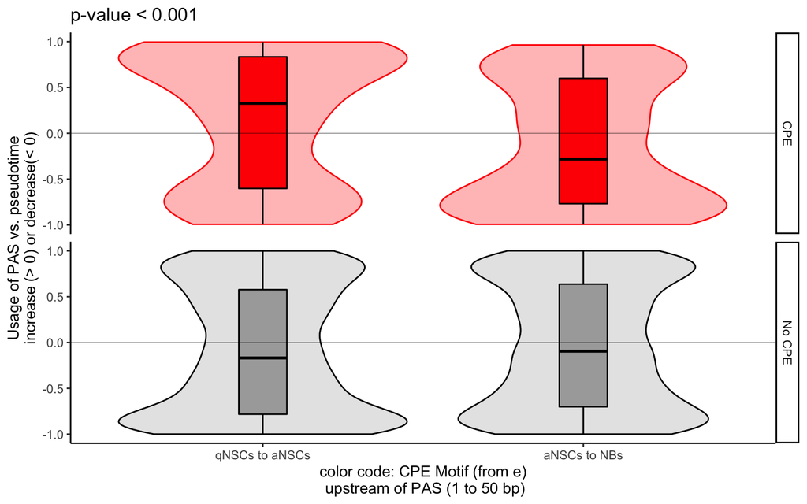

```r
gg_cpe_trend <- ggplot(cpe_cor_tbl, aes(y = Cor, x = Transition, color = Peak)) +
     geom_violin(mapping = aes(fill = Peak), alpha = .3) +
     geom_boxplot(width = .15, mapping = aes(fill = Peak), color = 'black' ) +
     theme_classic() +
     facet_grid(Peak~.) +
  scale_color_manual(values = c('red', 'black')) +
  scale_fill_manual(values = c('red', 'darkgrey')) +
  geom_hline(yintercept = 0, alpha = .5, size = 0.25) +
  guides(color = FALSE, fill = FALSE) +
  labs(x = 'color code: CPE Motif (from e)\n upstream of PAS (1 to 50 bp)',
       y = 'Usage of PAS vs. pseudotime\nincrease (> 0) or decrease(< 0)') +
  ggtitle('p-value < 0.001')

gg_cpe_trend
```